FJ

# Feidhelm Joyce

Business & Data Analyst  
Boston, MA

linkedin.com/in/feidhelmjoyce  
github.com/FeidhelmJ

MARKETING ANALYTICS

## Market Segmentation & Conjoint Analysis

← Back to Marketing Analytics

**Part I: Segmentation**

```
import pandas as pd
import numpy as np
import matplotlib.pyplot as plt
import seaborn as sns
from sklearn.cluster import KMeans
```

A. Read the dataset into your environment.

a. Take a look at the dataset description and at your data. Which of these variables should be seen as numeric? Which should be seen as categorical? Why is it not appropriate to use categorical inputs in a k-means model (even if the values are represented by numbers?)

Categorical Variables:

```
Day_ID
Day_of_Week
season_week_rel
Is_Holiday
Weather_Type
Is_Special_Event
```

Numeric Variables:

```
Total_Visitors
Passholder_Percentage
Day_Tickets_Sold
Avg_Ticket_Price
Gate_Revenue
Revenue_Food
Revenue_Merch
Revenue_Arcade
Total_Revenue
Total_Labor_Hours
International_Visitors
High_Temperature
Per_Capita_Spend
```

- It's innapropriate to use categorical inputs in a k-means model as these variables have no mathematical properties and would lead to an unreliable result, even if the values are represented by numbers!
- K-means clustering is achieved using centroids, which are centre points made up from the mean values of each feature within a group of observations. We cannot get mean values from categorical inputs.

```
days_25 = pd.read_csv('days25.csv')
```

```
pd.set_option('display.max_columns', None)
days_25.head()
```

|  | Day_ID | Day_of_Week | season_week_rel | Is_Holiday | Total_Visitors | Passholder_Percentage | Day_Tickets_Sold | Avg_Ticket_Price | Gate_Revenue | Revenue_Food | Revenue_Merch | Revenue_Arcade | Total_Revenue | Total_Labor_Hours | International_Visitors | High_Temperature | Weather_Type | Is_Special_Event | Per_Capita_Spend |
| --- | --- | --- | --- | --- | --- | --- | --- | --- | --- | --- | --- | --- | --- | --- | --- | --- | --- | --- | --- |
| 0 | 1 | Monday | 1 | 1 | 1769 | 48.65 | 908 | 77.42 | 70297.36 | 40521.91 | 15881.290 | 3195.46 | 129896.02 | 238.1 | 114.0 | 74.6 | Thunderstorms | 0 | 73.43 |
| 1 | 2 | Tuesday | 1 | 0 | 1717 | 60.58 | 677 | 69.80 | 47254.60 | 35298.92 | 15882.665 | 2977.63 | 101812.36 | 253.4 | 255.0 | 74.0 | Partly Cloudy | 0 | 59.30 |
| 2 | 3 | Wednesday | 1 | 0 | 1600 | 30.84 | 1107 | 70.09 | 77589.63 | 36495.95 | 14954.040 | 2683.58 | 131723.20 | 213.3 | 160.0 | 76.8 | Partly Cloudy | 0 | 82.33 |
| 3 | 4 | Thursday | 1 | 0 | 1037 | 19.02 | 840 | 72.30 | 60732.00 | 22486.65 | 9517.060 | 1831.98 | 94567.69 | 192.7 | 83.0 | 75.4 | Showers | 0 | 91.19 |
| 4 | 5 | Friday | 1 | 0 | 1671 | 66.18 | 565 | 68.11 | 38482.15 | 40705.15 | 15727.620 | 3115.94 | 98030.86 | 235.9 | 158.0 | 80.7 | Partly Cloudy | 0 | 58.67 |

```
days_25.columns
```

```
Index(['Day_ID', 'Day_of_Week', 'season_week_rel', 'Is_Holiday',
       'Total_Visitors', 'Passholder_Percentage', 'Day_Tickets_Sold',
       'Avg_Ticket_Price', 'Gate_Revenue', 'Revenue_Food', 'Revenue_Merch',
       'Revenue_Arcade', 'Total_Revenue', 'Total_Labor_Hours',
       'International_Visitors', 'High_Temperature', 'Weather_Type',
       'Is_Special_Event', 'Per_Capita_Spend'],
      dtype='object')
```

```
days_25.info()
```

```
<class 'pandas.core.frame.DataFrame'>
RangeIndex: 99 entries, 0 to 98
Data columns (total 19 columns):
 #   Column                  Non-Null Count  Dtype
---  ------                  --------------  -----
 0   Day_ID                  99 non-null     int64
 1   Day_of_Week             99 non-null     object
 2   season_week_rel         99 non-null     int64
 3   Is_Holiday              99 non-null     int64
 4   Total_Visitors          99 non-null     int64
 5   Passholder_Percentage   99 non-null     float64
 6   Day_Tickets_Sold        99 non-null     int64
 7   Avg_Ticket_Price        99 non-null     float64
 8   Gate_Revenue            99 non-null     float64
 9   Revenue_Food            99 non-null     float64
 10  Revenue_Merch           99 non-null     float64
 11  Revenue_Arcade          99 non-null     float64
 12  Total_Revenue           99 non-null     float64
 13  Total_Labor_Hours       99 non-null     float64
 14  International_Visitors  99 non-null     float64
 15  High_Temperature        99 non-null     float64
 16  Weather_Type            99 non-null     object
 17  Is_Special_Event        99 non-null     int64
 18  Per_Capita_Spend        99 non-null     float64
dtypes: float64(11), int64(6), object(2)
memory usage: 14.8+ KB
```

B. Call the describe() function on your dataset.

a. How does this function help you to gain an overall sense of the columns and values in this (or any other) dataset? Why is this valuable for any analyst who will use a dataset to build a model?

- Looking at the data from the numeric variables only, this gives the analyst a quick snapshot of the data and provides them with figures for metrics such as the mean, standard deviation, min, and max of the dataset.
- This can give the analyst a quick insight into variables that may contain missing values which is useful even for categorical variables, highlights any outliers or potential mistakes that may have got mixed up in the data. For example, the max value for high temperature is 200! I know this is in Fahrenheit and Maine does get hot in the summer but this is way above what we might expect which is backed up by the rest of the data for temperature so this is likely an error!

```
days_25.describe()
```

|  | Day_ID | season_week_rel | Is_Holiday | Total_Visitors | Passholder_Percentage | Day_Tickets_Sold | Avg_Ticket_Price | Gate_Revenue | Revenue_Food | Revenue_Merch | Revenue_Arcade | Total_Revenue | Total_Labor_Hours | International_Visitors | High_Temperature | Is_Special_Event | Per_Capita_Spend |
| --- | --- | --- | --- | --- | --- | --- | --- | --- | --- | --- | --- | --- | --- | --- | --- | --- | --- |
| count | 99.000000 | 99.000000 | 99.000000 | 99.000000 | 99.000000 | 99.000000 | 99.000000 | 99.000000 | 99.000000 | 99.000000 | 99.000000 | 99.000000 | 99.000000 | 99.000000 | 99.000000 | 99.000000 | 99.000000 |
| mean | 50.000000 | 7.575758 | 0.030303 | 1870.707071 | 41.973232 | 1098.292929 | 70.439697 | 79484.778182 | 54715.882626 | 18691.392273 | 4450.617879 | 147911.785253 | 256.535354 | 178.464646 | 77.126263 | 0.151515 | 76.930808 |
| std | 28.722813 | 4.100998 | 0.172292 | 641.078735 | 15.581994 | 466.750518 | 10.680450 | 37053.465251 | 97737.730733 | 8077.026667 | 2992.738130 | 62854.729274 | 47.232843 | 85.522800 | 13.975537 | 0.360375 | 12.582334 |
| min | 1.000000 | 1.000000 | 0.000000 | -50.000000 | 11.720000 | 322.000000 | -25.000000 | 22350.020000 | 22486.650000 | 9517.060000 | 1831.980000 | 63247.570000 | 192.700000 | -10.000000 | 63.800000 | 0.000000 | 51.630000 |
| 25% | 25.500000 | 4.000000 | 0.000000 | 1482.000000 | 28.895000 | 771.000000 | 68.250000 | 53853.740000 | 33291.365000 | 13492.635000 | 2693.595000 | 103186.105000 | 222.400000 | 117.500000 | 70.850000 | 0.000000 | 68.575000 |
| 50% | 50.000000 | 8.000000 | 0.000000 | 1704.000000 | 40.900000 | 995.000000 | 70.480000 | 70272.360000 | 38054.660000 | 15882.665000 | 3026.520000 | 129433.130000 | 243.500000 | 158.000000 | 74.800000 | 0.000000 | 77.500000 |
| 75% | 74.500000 | 11.000000 | 0.000000 | 2080.000000 | 54.590000 | 1411.000000 | 73.735000 | 103147.720000 | 55612.790000 | 22567.790000 | 5419.410000 | 184173.685000 | 272.000000 | 232.500000 | 81.350000 | 0.000000 | 84.385000 |
| max | 99.000000 | 15.000000 | 1.000000 | 3938.000000 | 73.650000 | 3029.000000 | 82.280000 | 242229.130000 | 999999.990000 | 51601.440000 | 15755.610000 | 423019.370000 | 435.400000 | 560.000000 | 200.000000 | 1.000000 | 110.860000 |

C. Missing values / Impossible values

a. Does this dataset contain any missing values? If so, how many? Which columns have missing values?

- The dataset does not contain any missing values.

b. What about impossible values? Do you see any impossible values here? If so, handle them in any way that you see fit. Why did you take this approach?

- There are some impossible values. The min values for total visitors, international visitors & average ticket price were -50, -10 & -25 respectively. Food revenue has what looks like a data error with max value coming in at just under 1 million dollars. As mentioned above, high temperature has a max value of 200 which is truly impossible!
- The -50 min value representing total visitors is likely a typo and should've been entered as +500. It is likely 500 and not 50 as the min value for gate revenue was still over 20k which could not have been accumulated by only 50 visitors.
- The -10 & -25 min values representing international visitors and average gate revenue are both also errors and likely should've been entered as 10 & 25.
- To mediate this issue I simply created a new data frame making some adjustments to the max & min values permitted for these columns. This would end up removing 5 rows from the dataset, however given that this only accounts for roughly 5% of the overall dataset, I felt this was okay.

```
days_25.isnull().sum()
```

|  | 0 |
| --- | --- |
| Day_ID | 0 |
| Day_of_Week | 0 |
| season_week_rel | 0 |
| Is_Holiday | 0 |
| Total_Visitors | 0 |
| Passholder_Percentage | 0 |
| Day_Tickets_Sold | 0 |
| Avg_Ticket_Price | 0 |
| Gate_Revenue | 0 |
| Revenue_Food | 0 |
| Revenue_Merch | 0 |
| Revenue_Arcade | 0 |
| Total_Revenue | 0 |
| Total_Labor_Hours | 0 |
| International_Visitors | 0 |
| High_Temperature | 0 |
| Weather_Type | 0 |
| Is_Special_Event | 0 |
| Per_Capita_Spend | 0 |

**dtype:** int64

```
days_25_new = days_25[(days_25['Avg_Ticket_Price'] > 0) & (days_25['Total_Visitors'] > 0) & (days_25['International_Visitors'] > 0) & (days_25['Revenue_Food'] < 120000) & (days_25['High_Temperature']< 105)]
days_25_new.describe()
```

|  | Day_ID | season_week_rel | Is_Holiday | Total_Visitors | Passholder_Percentage | Day_Tickets_Sold | Avg_Ticket_Price | Gate_Revenue | Revenue_Food | Revenue_Merch | Revenue_Arcade | Total_Revenue | Total_Labor_Hours | International_Visitors | High_Temperature | Is_Special_Event | Per_Capita_Spend |
| --- | --- | --- | --- | --- | --- | --- | --- | --- | --- | --- | --- | --- | --- | --- | --- | --- | --- |
| count | 94.000000 | 94.000000 | 94.000000 | 94.000000 | 94.000000 | 94.000000 | 94.000000 | 94.000000 | 94.000000 | 94.000000 | 94.000000 | 94.000000 | 94.000000 | 94.000000 | 94.000000 | 94.000000 | 94.000000 |
| mean | 51.010638 | 7.723404 | 0.031915 | 1889.893617 | 41.907872 | 1096.946809 | 71.445106 | 79359.761596 | 44963.396489 | 18745.566755 | 4469.163723 | 147756.848617 | 257.106383 | 181.851064 | 75.629787 | 0.159574 | 76.858723 |
| std | 28.951013 | 4.128069 | 0.176716 | 617.151878 | 14.990948 | 456.194812 | 4.578010 | 36387.056597 | 18713.198001 | 8206.433415 | 3036.328669 | 62623.620558 | 47.797683 | 84.721169 | 6.317969 | 0.368175 | 12.082934 |
| min | 1.000000 | 1.000000 | 0.000000 | 1037.000000 | 11.720000 | 322.000000 | 61.920000 | 22350.020000 | 22486.650000 | 9517.060000 | 1831.980000 | 63247.570000 | 192.700000 | 59.000000 | 63.800000 | 0.000000 | 51.630000 |
| 25% | 26.250000 | 4.000000 | 0.000000 | 1496.750000 | 30.345000 | 775.500000 | 68.222500 | 54061.460000 | 33205.287500 | 13474.397500 | 2688.587500 | 103754.537500 | 221.850000 | 118.250000 | 70.725000 | 0.000000 | 68.845000 |
| 50% | 52.500000 | 8.000000 | 0.000000 | 1697.000000 | 41.245000 | 986.500000 | 70.865000 | 69532.250000 | 37633.210000 | 15882.665000 | 3026.865000 | 128944.790000 | 243.700000 | 159.000000 | 74.450000 | 0.000000 | 77.465000 |
| 75% | 75.750000 | 11.000000 | 0.000000 | 2113.500000 | 54.257500 | 1356.000000 | 73.747500 | 100859.380000 | 54092.012500 | 22748.855000 | 5456.350000 | 176816.920000 | 273.550000 | 236.500000 | 80.800000 | 0.000000 | 83.957500 |
| max | 99.000000 | 15.000000 | 1.000000 | 3938.000000 | 73.650000 | 3029.000000 | 82.280000 | 242229.130000 | 116772.010000 | 51601.440000 | 15755.610000 | 423019.370000 | 435.400000 | 560.000000 | 91.400000 | 1.000000 | 110.860000 |

D. Variable selection. Select any 5 variables from the potential set of inputs in order to build your k-means clustering model.

a. Why did you choose this set of 5 variables? (Note: this can be subjective. You don’t need to do any rigorous data analysis here). One sentence per variable, or a single paragraph that explains how they connect as a theme, will be fine here. Be sure that you’re only using these five variables going forward for any modeling purposes from this point.

5 Variables:

```
Total Visitors
Total Revenue
High Temperature
Passholder Percentage
Per Capita Spend
```

E. Data scaling.

a. Do your variables need to be standardized? Why or why not?

b. If your data requires standardization, use Python to convert your values into z-scores, and store the normalized data in a new dataframe. If not, proceed to the next step without changing the variables

- Yes my variables need to be standardized because they are measured on different scales and their ranges and units are unique. For example, Total visitors is measured in the thousands of people, total revenue measured in the tens of thousands of dollars and temperature measured in Fahrenheit. If I didn't standardize the data, the model would be dominated by the values for total revenue.

```
days_25_means = days_25_new[['Total_Visitors', 'Total_Revenue', 'High_Temperature', 'Passholder_Percentage', 'Per_Capita_Spend']].mean()
days_25_stds = days_25_new[['Total_Visitors', 'Total_Revenue', 'High_Temperature', 'Passholder_Percentage', 'Per_Capita_Spend']].std()
```

```
days_25_zscores = (days_25_new[days_25_means.index]-days_25_means)/days_25_stds
days_25_zscores.head()
```

|  | Total_Visitors | Total_Revenue | High_Temperature | Passholder_Percentage | Per_Capita_Spend |
| --- | --- | --- | --- | --- | --- |
| 0 | -0.195890 | -0.285209 | -0.162993 | 0.449747 | -0.283766 |
| 1 | -0.280148 | -0.733661 | -0.257961 | 1.245560 | -1.453184 |
| 2 | -0.469728 | -0.256032 | 0.185220 | -0.738304 | 0.452810 |
| 3 | -1.381983 | -0.849347 | -0.036370 | -1.526780 | 1.186076 |
| 4 | -0.354684 | -0.794045 | 0.802507 | 1.619119 | -1.505323 |

```
round(days_25_zscores.describe(),2)
```

|  | Total_Visitors | Total_Revenue | High_Temperature | Passholder_Percentage | Per_Capita_Spend |
| --- | --- | --- | --- | --- | --- |
| count | 94.00 | 94.00 | 94.00 | 94.00 | 94.00 |
| mean | -0.00 | -0.00 | -0.00 | -0.00 | -0.00 |
| std | 1.00 | 1.00 | 1.00 | 1.00 | 1.00 |
| min | -1.38 | -1.35 | -1.87 | -2.01 | -2.09 |
| 25% | -0.64 | -0.70 | -0.78 | -0.77 | -0.66 |
| 50% | -0.31 | -0.30 | -0.19 | -0.04 | 0.05 |
| 75% | 0.36 | 0.46 | 0.82 | 0.82 | 0.59 |
| max | 3.32 | 4.40 | 2.50 | 2.12 | 2.81 |

F. Elbow chart.

b. Build an elbow chart to help give you a sense of how you might build your model.

c. How many clusters will you use for your k-means model? (Remember, as noted in several places throughout the course material, there is no “right” answer to this question. You may wish to answer this immediately after seeing your elbow plot, or after doing some more experimentation). * Looking at the elbow chart below, I will use 4 clusters for my k-means model as this looks like the best "bang for the buck".

```
sse = {}

for k in range(1,10):
  kmeans = KMeans(n_clusters = k, random_state = 654)
  kmeans.fit(days_25_zscores)
  sse[k] = kmeans.inertia_
plt.title('The Elbow Method')
plt.xlabel('k')
plt.ylabel('SSE')
sns.pointplot(x=list(sse.keys()), y=list(sse.values()))
plt.show()
```

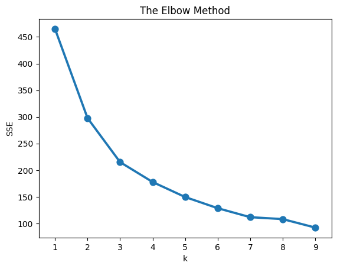

G. Build a k-means model with your desired number of clusters

```
kmeans = KMeans(n_clusters = 4, random_state = 654)
kmeans.fit(days_25_zscores)
cluster_labels = kmeans.labels_
```

H.

Generate the centroid values (i.e., the mean values of each variable for each cluster) and display them.

```
kmeans2 = days_25_zscores.assign(Cluster = cluster_labels)
kmeans2.groupby(['Cluster']).agg({
    'Total_Visitors': 'mean',
    'Total_Revenue': 'mean',
    'High_Temperature': 'mean',
    'Passholder_Percentage': 'mean',
    'Per_Capita_Spend': 'mean'
}).round(2)
```

| Cluster | Total_Visitors | Total_Revenue | High_Temperature | Passholder_Percentage | Per_Capita_Spend |
| --- | --- | --- | --- | --- | --- |
| 0 | -0.27 | -0.38 | 1.15 | 0.45 | -0.39 |
| 1 | -0.54 | -0.78 | -0.51 | 0.99 | -1.12 |
| 2 | -0.57 | -0.31 | -0.37 | -0.90 | 0.55 |
| 3 | 1.56 | 1.56 | -0.02 | -0.25 | 0.80 |

I.

Build any four simple visualizations to help management better understand your clusters (a simple visualization could be a histogram, a barplot, a scatterplot, etc.) You may wish to facet your visualizations by cluster.For each one of your visualizations, include 2-3 sentences of description/ explanation. What does it show about your model?

```
updated_days = days_25_new.assign(Cluster = cluster_labels)
updated_days.dtypes
```

|  | 0 |
| --- | --- |
| Day_ID | int64 |
| Day_of_Week | object |
| season_week_rel | int64 |
| Is_Holiday | int64 |
| Total_Visitors | int64 |
| Passholder_Percentage | float64 |
| Day_Tickets_Sold | int64 |
| Avg_Ticket_Price | float64 |
| Gate_Revenue | float64 |
| Revenue_Food | float64 |
| Revenue_Merch | float64 |
| Revenue_Arcade | float64 |
| Total_Revenue | float64 |
| Total_Labor_Hours | float64 |
| International_Visitors | float64 |
| High_Temperature | float64 |
| Weather_Type | object |
| Is_Special_Event | int64 |
| Per_Capita_Spend | float64 |
| Cluster | int32 |

**dtype:** object

```
updated_days['Cluster'] = updated_days['Cluster'].astype('category')
```

```
sns.barplot(x = 'Cluster', y = 'Total_Visitors', data = updated_days, errorbar=None)
plt.title('Total Visitors by Cluster')
plt.xlabel('Cluster')
plt.ylabel('Total Visitors');
```

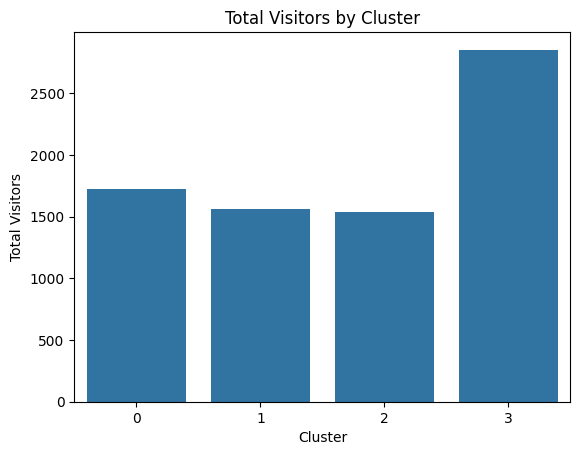

```
sns.countplot(x = 'Cluster', data = updated_days)
plt.title('Count of Days by Clusters')
plt.xlabel('Cluster')
plt.ylabel('Count');
```

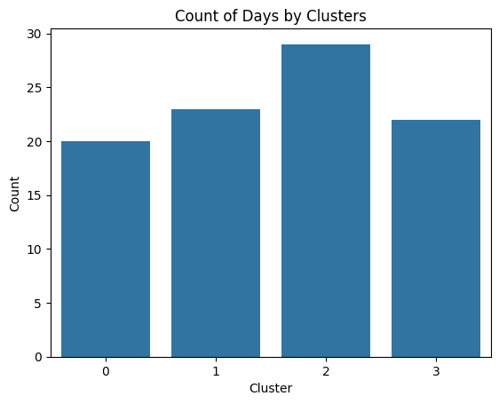

- I wanted to see a spread of how the days were allocated to different clusters to ensure that there was no one or two clusters taking the majority of the data.
- As expected, days that fell into cluster 3 didn't account for the bulk of the data despite the high visitor count & revenue statistics. This was due to these days predominantly falling on weekends and holidays.
- This was more so a test to get a handle on what cluster if any dominated the data count, the graph clearly shows that this wasn't the case aside from cluster 2's count being slightly higher.

```
sns.scatterplot(x = 'Passholder_Percentage', y = 'Per_Capita_Spend', hue = 'Cluster', data = updated_days)
plt.title('Passholder Percentage vs Per Capita Spend by Cluster')
plt.xlabel('Passholder Percentage')
plt.ylabel('Per Capita Spend');
```

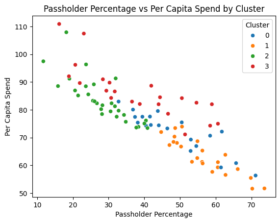

- This scatter plot helps us visualize and confirm what the centroid values from above showed us.
- We can see that the passholder percentage tends to be lower on days that fall into clusters 2 & 3, these are also days when per capita spend is the highest.
- This shows us that passholders tend to spend less at the park with the majority of the days where passholder percentage is high and per capita spend is low falling into cluster one. That being said as we've already mentioned, days in clusters 2/3 are likely weekends or holidays where people tend to spend more.

```
faceted_plot = sns.FacetGrid(updated_days, col="Cluster", col_wrap=2, height=4, sharex=False, sharey=False)
faceted_plot.map_dataframe(sns.histplot, x="Total_Revenue", bins=10, color="blue", edgecolor="black")
faceted_plot.set_axis_labels("Total Revenue", "Count")
faceted_plot.set_titles("Cluster {col_name}")
plt.subplots_adjust(bottom=0.001, top=0.9)
faceted_plot.fig.subplots_adjust(hspace=0.3)
faceted_plot.set_xticklabels(rotation=45, ha="right")
faceted_plot.fig.suptitle("Distribution of Total Revenue Across Clusters")
plt.show()
```

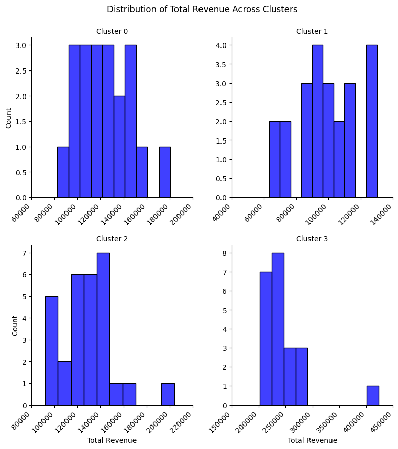

- As previously noted, the revenue on days that fell into clusters 2 & especially 3 were greater than clusters 0 & 1, the plots above show us a visualization proving this.
- From the plot we can see that every day from cluster 3 generated at least 200k in revenue for Lobster Land with the majority falling into the 200 - 250k range, there was one outlier, a day management will hope they can replicate again where revenue for the park surpassed 400k.
- The spread of revenue on days in cluster 0 ranged from roughly 80 - 180k. Cluster 1, the days where the most passholders & likely locals attend the park's revenue ranged from lows of around 65k to roughly 130k.

J.

Give a descriptive name to each one of your clusters, along with a few sentences of explanation for the name that you chose. Keep in mind that the data itself is describing days (not visitors) – here in this step, you’re describing clusters of day types

```
kmeans2 = days_25_zscores.assign(Cluster = cluster_labels)
kmeans2.groupby(['Cluster']).agg({
    'Total_Visitors': 'mean',
    'Total_Revenue': 'mean',
    'High_Temperature': 'mean',
    'Passholder_Percentage': 'mean',
    'Per_Capita_Spend': 'mean'
}).round(2)
```

| Cluster | Total_Visitors | Total_Revenue | High_Temperature | Passholder_Percentage | Per_Capita_Spend |
| --- | --- | --- | --- | --- | --- |
| 0 | -0.27 | -0.38 | 1.15 | 0.45 | -0.39 |
| 1 | -0.54 | -0.78 | -0.51 | 0.99 | -1.12 |
| 2 | -0.57 | -0.31 | -0.37 | -0.90 | 0.55 |
| 3 | 1.56 | 1.56 | -0.02 | -0.25 | 0.80 |

```
updated_days['Cluster'] = updated_days['Cluster'].cat.rename_categories({0: 'Warm day for regulars',
                                                                         1: 'Locals day',
                                                                         2: 'Tourists day',
                                                                         3: 'Big Spenders day'})
```

- Warm day for regulars - These are days where the temperature is highest relative to the mean. The passholder percentage is also relatively high with total visitors & revenue being low relative to the mean. This would indicate these are likely midweek days.
- Locals day - Again, likely a midweek day, these are days where the locals come out. The passholder percentage is the highest of the four clusters here and per capita spend is lowest. Locals are less likely to spend money at the park as they are visiting more often than tourists, this is emphasised by the total revenue z score.
- Tourists day - These are days where the most tourists or 'one off vistors' visit the park. This is emphsised by the extremely low passholder percentage score but high per capita spend, which makes sense as tourists are more likely to spend a greater amount at the park if this is to be their only visit.
- Big Spenders day - These are likely public holidays or certain days across different weekends. There are high levels of visitors to the park but not only that, the visitors that do come on these days are spending a lot of money, shown by the high per capita spend here.

K.

For each cluster, also include a couple sentences about targeting. What types of visitors would be interested in attending the park on the day types you have identified, and how should Lobster Land reach them? You can exercise some ‘creative freedom’ here with this answer. A good answer will go beyond just saying “send a coupon” to each group.

- Warm day for regulars - Looking at the data, visitors to the park is the actaully the second highest across the four clusters so getting people to the park maybe shouldn't be top priority. Passholder % here is relatively high so management could maybe implement promotional events through the food, beverage & merchandise stands to try and drum up so more revenue as per capita spend is quite low here.
- Locals day - The data for days that fall into this cluster is not pretty reading for management. The centroid values are well below the mean across every variable besides passholder %. For this reason management needs to try and lure more tourists and 'once off' visitors to the park as they tend to spend more than the locals. This could be achieved through a promotion at the gate or even running special events on these days to get increased footfall into the park.
- Tourists day - This is actually quite a profitable day for Lobster Land, although footfall into the park is the lowest across the 4 clusters, per capita spend is the second highest being only eclipsed by the weekend & holiday days that fall into cluster 3. The emphasis for management should be to get more people into the park on this days, this could be achieved again through a promotional event ran at the gate. Management could even partner with travel agencies from around the area to try and get people from all the corners of New England to come to Labster Land, arranging transport to and from the park and some free arcade coupons, as revenue here tends to be quite low.
- Big Spenders day - Days in this cluster are the money makers, again wihtout running the risk of repeating myself, it is mostly weekends and holidays where attendance & revenue are both high. We can see that passholder % is lower than the mean so the management could try and drive this figure down even lower, to deter the locals from coming on these days! A 'first time visitor' offer might be the best way to achieve this, I do feel people will attend the park on these days regardless but a small discount for first timers on the weekends could generate further revenue.

L.

How can Lobster Land use this model? Write a couple paragraphs’ worth of thoughts assessing how Lobster Land might apply the results. You could explore “what if” scenarios, or how the park’s priorities might shape their decisions

The k-means clustering analysis gives Lobster Land a clearer picture of how different kinds of operational days naturally group together based on real park data. Because all variables were standardized using z-scores before modeling, no single metric—such as revenue, attendance, or temperature—was allowed to dominate the results. Each factor carried equal weight, allowing the algorithm to uncover patterns that reflect the overall shape of a day’s performance rather than the scale of its numbers.

By mapping clusters to days of the week or months of the season, the park can forecast what kind of day it’s heading into and prepare accordingly. For instance, if Cluster 3 is mostly made up of weekend days with large crowds, the operations team can plan more entertainment offerings or open additional food stalls. Similarly, if Cluster 1 corresponds to cooler, lower-attendance weekdays, marketing could run mid-week ticket promotions to boost turnout. Days in clusters characterized by high visitor counts and above-average revenue might call for increased staff levels, extended park hours, and higher inventory in dining or merchandise areas. Conversely, clusters with fewer visitors but higher per-capita spending might suggest an opportunity to focus on premium experiences or targeted marketing to passholders and tourists.

Overall, this model helps Lobster Land make decisions that are both data-driven and proactive. Instead of reacting to crowds after they arrive, the park can anticipate demand, allocate resources efficiently, and design strategies tailored to each of the days that fall into different cluster's behavior pattern.

**Part II: Conjoint Analysis with a Linear Model**

A.

Read the dataset night_show.csv into your local environment in Jupyter Notebook or Colab

```
from sklearn.linear_model import LinearRegression
from sklearn import metrics
```

```
night_show = pd.read_csv("night_show.csv", keep_default_na=False, na_values=[])
night_show.head()
```

|  | bundleID | headliner | music_atmosphere | show_length | peak_dB_Level | crowding_index | viewing_zone | dining_bundle | re_entry | live_host | charity_tie_in | ratings |
| --- | --- | --- | --- | --- | --- | --- | --- | --- | --- | --- | --- | --- |
| 0 | 1 | Fireworks | Pop Soundtrack | 30 | 65 | 40 | front plaza | None | None | Yes | Yes | 4.249 |
| 1 | 2 | Fireworks | Pop Soundtrack | 30 | 65 | 40 | front plaza | None | None | Yes | No/Doesn't Matter | 4.689 |
| 2 | 3 | Fireworks | Pop Soundtrack | 30 | 65 | 40 | front plaza | None | None | No/Doesn't Matter | Yes | 7.999 |
| 3 | 4 | Fireworks | Pop Soundtrack | 30 | 65 | 40 | front plaza | None | None | No/Doesn't Matter | No/Doesn't Matter | 4.309 |
| 4 | 5 | Fireworks | Pop Soundtrack | 30 | 65 | 40 | front plaza | None | One | Yes | Yes | 6.239 |

```
night_show.tail()
```

|  | bundleID | headliner | music_atmosphere | show_length | peak_dB_Level | crowding_index | viewing_zone | dining_bundle | re_entry | live_host | charity_tie_in | ratings |
| --- | --- | --- | --- | --- | --- | --- | --- | --- | --- | --- | --- | --- |
| 73723 | 73724 | Character Parade | Classic Orchestra | 150 | 105 | 100 | boardwalk | dessert_party | One | No/Doesn't Matter | No/Doesn't Matter | 5.37 |
| 73724 | 73725 | Character Parade | Classic Orchestra | 150 | 105 | 100 | boardwalk | dessert_party | Unlimited | Yes | Yes | 4.85 |
| 73725 | 73726 | Character Parade | Classic Orchestra | 150 | 105 | 100 | boardwalk | dessert_party | Unlimited | Yes | No/Doesn't Matter | 6.67 |
| 73726 | 73727 | Character Parade | Classic Orchestra | 150 | 105 | 100 | boardwalk | dessert_party | Unlimited | No/Doesn't Matter | Yes | 5.53 |
| 73727 | 73728 | Character Parade | Classic Orchestra | 150 | 105 | 100 | boardwalk | dessert_party | Unlimited | No/Doesn't Matter | No/Doesn't Matter | 1.25 |

```
night_show.isnull().values.any()
```

```
np.False_
```

B.

Based on the descriptions shown above, which of your variables are numeric, and which are categorical? (The standard you should use when answering this is that something that is both represented by a number, and for which that number has valid mathematical meaning, is numeric)

Categorical:

```
Bundle ID
Headliner
Music_atmosphere
Crowding Index
Peak_db_level
Viewing_zone
Dining_Bundle
Re_entry
Live_host
Charity_tie_in
```

Numeric:

```
Show_length
Ratings
```

```
night_show.info()
```

```
<class 'pandas.core.frame.DataFrame'>
RangeIndex: 73728 entries, 0 to 73727
Data columns (total 12 columns):
 #   Column            Non-Null Count  Dtype
---  ------            --------------  -----
 0   bundleID          73728 non-null  int64
 1   headliner         73728 non-null  object
 2   music_atmosphere  73728 non-null  object
 3   show_length       73728 non-null  int64
 4   peak_dB_Level     73728 non-null  int64
 5   crowding_index    73728 non-null  int64
 6   viewing_zone      73728 non-null  object
 7   dining_bundle     73728 non-null  object
 8   re_entry          73728 non-null  object
 9   live_host         73728 non-null  object
 10  charity_tie_in    73728 non-null  object
 11  ratings           73728 non-null  float64
dtypes: float64(1), int64(4), object(7)
memory usage: 6.8+ MB
```

C.

Use the pandas get_dummies() function in order to prepare these variables for use in a linear model. Inside this function, include this argument: drop_first = True. Doing this will save us from the multicollinearity problem that would make our model unreliable. Be sure to dummify ALL of your input variables, even the numeric ones.

a. Why should the numeric input variables based on this survey data be dummified?

- If we don’t dummify the numeric values, we’d be implying that there’s a continuous range of options between the values which is incorrect.
- By creating dummy variables, we ensure the model correctly treats each level as a separate choice option. For example, in the show length variable, there are ony 4 options; 30, 70, 110 & 150. We need to ensure that the model takes these 4 values as the only options for this choice and not everything in between.

```
night_show.columns
```

```
Index(['bundleID', 'headliner', 'music_atmosphere', 'show_length',
       'peak_dB_Level', 'crowding_index', 'viewing_zone', 'dining_bundle',
       're_entry', 'live_host', 'charity_tie_in', 'ratings'],
      dtype='object')
```

```
night_show_2 = pd.get_dummies(night_show, drop_first=True, columns=['headliner', 'music_atmosphere', 'show_length',
       'peak_dB_Level', 'crowding_index', 'viewing_zone', 'dining_bundle',
       're_entry', 'live_host', 'charity_tie_in'])
```

```
night_show_2.head()
```

|  | bundleID | ratings | headliner_Drone Light Show | headliner_Fireworks | headliner_Live Musical | music_atmosphere_Pop Soundtrack | show_length_70 | show_length_110 | show_length_150 | peak_dB_Level_85 | peak_dB_Level_105 | crowding_index_60 | crowding_index_80 | crowding_index_100 | viewing_zone_boardwalk | viewing_zone_castle_courtyard | viewing_zone_front plaza | dining_bundle_dessert_party | dining_bundle_meal_package | dining_bundle_snack_voucher | re_entry_One | re_entry_Unlimited | live_host_Yes | charity_tie_in_Yes |
| --- | --- | --- | --- | --- | --- | --- | --- | --- | --- | --- | --- | --- | --- | --- | --- | --- | --- | --- | --- | --- | --- | --- | --- | --- |
| 0 | 1 | 4.249 | False | True | False | True | False | False | False | False | False | False | False | False | False | False | True | False | False | False | False | False | True | True |
| 1 | 2 | 4.689 | False | True | False | True | False | False | False | False | False | False | False | False | False | False | True | False | False | False | False | False | True | False |
| 2 | 3 | 7.999 | False | True | False | True | False | False | False | False | False | False | False | False | False | False | True | False | False | False | False | False | False | True |
| 3 | 4 | 4.309 | False | True | False | True | False | False | False | False | False | False | False | False | False | False | True | False | False | False | False | False | False | False |
| 4 | 5 | 6.239 | False | True | False | True | False | False | False | False | False | False | False | False | False | False | True | False | False | False | True | False | True | True |

D.

It might seem tempting here to just skip the model-building step – instead of building a model, we could just rank the bundles by average rating, in descending order, and then just tell Lobster Land to implement all the features in the highest-rated bundle.

What would we miss by doing this, though? What value does a conjoint analysis model provide, which we would not have if we simply ranked the bundles?

- Conjoint analysis delivers insights about particular levels and particular attributes. It teaches us about the sorts of things that make products more appealing to less appealing to consumers
- Bundles are combinations of multiple features. If you just rank bundles, you don’t know which features are driving high ratings, this is essential when analyzing variables like crowding index where there are four options respondents can choose from.
- If you just average ratings, you’re limited to the bundles that were shown. Conjoint analysis builds a model that can help management predict customer preferences for new, untested bundles by assessing the coefficeint values of the current model. For example, below I will highlight that respondents really did not like the unlimited re-entry option, therefore Lobster Land can make this adjustment to remove this option for any future testing or for the event itself.

E.

Build a linear model with your data, using the average rating as the outcome variable, and with all of your other variables (other than the bundleID) as inputs.

```
night_show_2.columns
```

```
Index(['bundleID', 'ratings', 'headliner_Drone Light Show',
       'headliner_Fireworks', 'headliner_Live Musical',
       'music_atmosphere_Pop Soundtrack', 'show_length_70', 'show_length_110',
       'show_length_150', 'peak_dB_Level_85', 'peak_dB_Level_105',
       'crowding_index_60', 'crowding_index_80', 'crowding_index_100',
       'viewing_zone_boardwalk', 'viewing_zone_castle_courtyard',
       'viewing_zone_front plaza', 'dining_bundle_dessert_party',
       'dining_bundle_meal_package', 'dining_bundle_snack_voucher',
       're_entry_One', 're_entry_Unlimited', 'live_host_Yes',
       'charity_tie_in_Yes'],
      dtype='object')
```

```
X = night_show_2[['headliner_Drone Light Show',
       'headliner_Fireworks', 'headliner_Live Musical',
       'music_atmosphere_Pop Soundtrack', 'show_length_70', 'show_length_110',
       'show_length_150', 'peak_dB_Level_85', 'peak_dB_Level_105',
       'crowding_index_60', 'crowding_index_80', 'crowding_index_100',
       'viewing_zone_boardwalk', 'viewing_zone_castle_courtyard',
       'viewing_zone_front plaza', 'dining_bundle_dessert_party',
       'dining_bundle_meal_package', 'dining_bundle_snack_voucher',
       're_entry_One', 're_entry_Unlimited', 'live_host_Yes',
       'charity_tie_in_Yes']]
Y = night_show_2['ratings']
```

```
regressor = LinearRegression()
regressor.fit(X, Y)
```

```
LinearRegression()
```

```
regressor.intercept_
```

```
np.float64(4.953266755574281)
```

F.

Display the coefficient values of your model inputs.

```
coef_df = pd.DataFrame(regressor.coef_, X.columns, columns=['Coefficient'])
coef_df
```

|  | Coefficient |
| --- | --- |
| headliner_Drone Light Show | 0.017789 |
| headliner_Fireworks | 0.000853 |
| headliner_Live Musical | 1.029869 |
| music_atmosphere_Pop Soundtrack | -0.713001 |
| show_length_70 | 0.717907 |
| show_length_110 | 0.970937 |
| show_length_150 | 0.703843 |
| peak_dB_Level_85 | 0.016527 |
| peak_dB_Level_105 | -0.887189 |
| crowding_index_60 | 0.223038 |
| crowding_index_80 | 0.232322 |
| crowding_index_100 | -0.604624 |
| viewing_zone_boardwalk | 0.388865 |
| viewing_zone_castle_courtyard | 0.356038 |
| viewing_zone_front plaza | 0.338891 |
| dining_bundle_dessert_party | -0.002845 |
| dining_bundle_meal_package | 0.003259 |
| dining_bundle_snack_voucher | -0.092152 |
| re_entry_One | 0.296802 |
| re_entry_Unlimited | -1.592003 |
| live_host_Yes | 0.842467 |
| charity_tie_in_Yes | 0.241810 |

G.

Write two-three paragraphs for Lobster Land management about what your model is showing you

Headliner:

For the headliner options, the base coefficient that was chosen here was the Characacter Parade which was kid-themed. It was the most poorly rated coefficient out of the four given options however it fell just behind the Drone Light Show & Fireworks headliners. It is unsurpising that the Character Parade was the lowest rated headliner as it catered almost exclusively to children. It is also unsurprising to see that the Live Musical was the highest rated coefficient as a live musical caters towards people of all ages, demographics & backgrounds.

Music Atmosphere:

Between the two options for music atmosphere, the Live Classical Orchestra was receieved much better than the Pop Soundtrack which was recorded. There seems to be a trend forming among park visitors preferences with a live performance again being the most preffered option which is something to note for management.

Show Length:

For the show length, the base coefficient that was chosen here was 30 minutes and this was very poorly rated among visitors when compared to the other options. 110 minutes was the most preferred option here with visitors being mostly indifferent about whether they preffered a show of 70 or 150 minutes in length. Personally these values make sense to me, 30 minutes is far too short for a show length given there is more than likely going to be a cost to get in. 110 minutes seems to be long enough that people will get their money's worth, but not too long that they become bored. Management should conduct another survey surrounding show length, remove 30 minutes as an option to try and differentiate between the 70 & 150 minute options.

Peak DB Level:

65 was selected as the base coefficient here. Unsurprisingly, 105 scored terribly among the 3 options with db levels of 65 & 85 scoring almost identically, for Lobster Land management, its evident they should keep db levels below 90.

Viewing Zone

There isn't much to report for viewing zone aside from the respondents tended to prefer the boardwalk, castle courtyard & the front plaza equally when compared against the sandy beach viewing zone. This is to be expected as the weather will be slightly too chilly this time of year to be spending time on the beach. If a show is to be ran over the summer months visitors opinion may differ here but in my opinion the management team should remove this option and get visitors preferences between the remaining three viewing zones.

Re-Entry

In terms of re-entry, visitors felt positively about being able to re-enter the show once, which is likely to accomodate people's bathroom needs. On the flip side they felt really strongly against unlimited re-entries. This makes sense because if people are trying to sit down and enjoy a show which they've paid an admission fee for, the last thing they want is a constant flow of people coming and going, potentially obstructing their view.

Live Host

I would recommend Lobster Land to hire a live host for the event as apposed to an automated voice. Again, following on from the theme earlier of the live musical & atmosphere, the respondents answered very positively about a live emmcee, a good emmcee can make or break any event!

Charity Tie-in

The respondents defintely leaned more towards having a charity tie in with the event as apposed to not having one. I personally think this would be a fantastic idea for the Lobster Land management team to implement. Given the summer months are over, it is likely that the majority of the visitors to the park for these events will be locals & passholders, it would be a fantastic initiative for the park to support a local charity each night and potentially even give a % of the revenue from the gate.

**Part III: Wildcard: Marketing & Segments**

A. Find ANY advertisement…ANYWHERE. As you walk around in your daily life, you might look for an ad on the side of the T, on a bus stop, on a poster, etc. Alternatively, you could use an advertisement that you encounter while browsing the web.

a. Take a picture of the ad that you see (if it’s in the ‘real world’). Or, if the ad you select is online, take a screenshot from your phone or your laptop to capture this advertisement.

b. Write ONE thoughtful paragraph that addresses the issue of segmentation. What consumer segment is your ad targeting? What makes you think this? What types of consumers are in the segment? Are you part of the segment? Or,alternatively, is your ad an undifferentiated (mass market) ad? Finally, what is your opinion of this ad – is it effective?

Link to the Advert:

https://www.youtube.com/watch?v=t4hmFPBf-C8

This ad is firstly targeting Irish people as a whole and then Irish beer drinkers (which yes is about 90% of the population!), for this reason it is somewhat mass marketing. The advert was released in 1980, at the time Harp lager would have been one of the most famous beers in Ireland. It is still a popular beer today but lagers from overseas such as Coors Light, Heineken & Carsleberg dominate the lager beer market. At the time, emigration from Ireland was extremely high to places such as America, England and Australia so Harp was attempting to capatilize on this with a quick reminder of home for those who had left. I feel it resonates greatly with people of my generation today as emigration statistics are again extremely high due to economic factors in Ireland.

I personally love this ad! Harp was originally brewed in my home town of Dundalk up until it moved to St James' Gate in Dublin in 2013, so I would remember walking to school every day and getting the smell from the brewery (terrible!). Harp has traditionally been Ireland's most prominent domestically brewed lager so it would be quite famous among Irish beer drinkers of a certain generation, especially those from Dundalk. Is this ad effective? Absolutely.